# IT7071 Data Mining & Machine Learning - Course Project

## COVID-19 Data Collection and Analysis

#### Submitted to: Dr. Cheng Cheng Li

#### Submitted by: Muthu Vadivu ShanmugaSundaram

## Covid-19 and Partisanship of States in the United States

### Abstract:

The response to COVID-19 in the United States has mostly been political. A high level of political polarization is observed among leaders and public. Unlike many other countries, different states in the United States follow different levels of restrictions and do not have the same set of rules. The promptness of action and circumstances of states vary based on the Governors. Also there is an uneven public response to the pandemic across states. Actions of people, on following orders and restrictions put in place, are consistent with the party they follow or believe in. In this paper, we study if there is a significant difference in covid impact, in terms of cases per capita, based on political partisanship of states. More precisely, we research if there is a difference in covid cases per 100k between the states in which Republican and Democratic Governors rule and if there is a significant difference of the same between the red and blue states. We present data on cases per 100k across 50 states and District of Columbia with the party to which each state Governor belongs to and the partisanship of people in the state based on the last 4 presidential elections. On analyzing, we find evidence that there is no significant difference in the means of 'covid cases per 100k' between Republican and Democratic states or between Red and Blue states.

### Introduction:

The number of coronavirus cases surge across the globe, with more than 19 million reported cases in 188 countries and 700,000 fatalities. The United States is one of the worst-hit countries with at least 4,688,000 cases and 152,000 fatalities. Governors across the country are imposing or lifting restrictions for their state residents and there are substantial variations in how the pandemic is handled in each state. American governors thus play an immense role in making life and death decisions during the time of this outbreak.

There are increased concerns and questions on the implications of the political partisanship of states on the pandemic and the consequences this could lead to. There is no doubt about the partisan diconnect in the response to this virus but with all the speculations, it is important to analyze whether this disparity has anything to do with the coronavirus impact in the states.

One other factor to consider is the public attitude towards this pandemic. Public response and behavior are influenced by the political elites. There is a widened gap between how the republicans and the democrats are concerned about the spread of the virus. A study published by Pew Research Center in the month of June stated that the differences between Republicans' and Democrats' levels of comfort far exceeds other demographic and geographic differences.

Therefore, it is imperative to evaluate if there is a correlation between covid cases and the partisanship of the governor of the state. We will also analyze if there is a correlation between covid cases and the political partisanship of the people in the state(conservatives or liberals). Red states are states that were carried by the Republicans in the last 3-4 presidential elections and Blue states are states that were carried by Democrats in the last 3-4 presidential elections. For convenience, we will ignore the three swing states where each party won twice in the last four presidential elections.

For this research, we will consider the covid cases per capita (covid cases per 100k) as population varies across states and the number of covid cases will not be the right indicator to measure the impact. Therefore, below are the two research questions for which we will find answers as part of this research.

1. Is there a mean difference in covid cases per capita between states ruled by Republican and Democratic Governors?
2. Is there a mean difference in covid cases per capita between Red and Blue States?

One might wonder why we must be testing both the questions, assuming that Red States will have Republican Governors and Blue States will have Democratic Governors. But this is not always the case. For example, Kentucky is a red state with a Democratic Governor. Similarly there are few other places where the partisanship of the state is different from that of the Governor. Hence, there is a need to verify both the cases.

### Data Collection/Processing:

Data for this study will be collected from online sources. For the number of covid cases per 100k, we downloaded data(on 24 July 2020) as excel from datausa.io/coronavirus website managed by Deloitte and Datawheel. For data on party to which each Governor belongs to, we will scrape data from Wikipedia using BeautifulSoup. We will then assign both the tables to Pandas Dataframe, remove the columns that are not required and merge the tables. We will also download data on red and blue states from Wikipedia and assign the table to pandas dataframe from excel.

#### Research Question 1:

```python
#Import all the required packages
import pandas as pd
import numpy as np
import scipy as sp
import seaborn as sns
import xlrd
import requests
import re
from scipy.stats import ttest_ind
from matplotlib import pyplot as plt
%matplotlib inline
from bs4 import BeautifulSoup
```

```python
#Data collected from datausa.io/coronavirus on 24th July 2020

#Import data from excel and assign to a Pandas Dataframe
df_coronaCases = pd.DataFrame(pd.read_excel('COVID19_StateWise.xlsx'))

#Remove all the columns that are not required
del df_coronaCases['14-DAY TREND OF NEW CASES']
del df_coronaCases['14-DAY NEW']
del df_coronaCases['14-DAY NEW CASES']
del df_coronaCases['CONFIRMED']
del df_coronaCases['CONFIRMED.1']
del df_coronaCases['% POSITIVE']
del df_coronaCases['TOTAL.1']
del df_coronaCases['TOTAL VS NEW CASES']
del df_coronaCases['TOTAL']

#Rename the column headings appropriately
df_coronaCases= df_coronaCases.rename(index=str, columns={"CASES PER": "CASES PER 100k"})
df_coronaCases = df_coronaCases.drop(df_coronaCases.index[0])
df_coronaCases
```

|  | STATE | CASES PER 100k |
| --- | --- | --- |
| 1 | Alabama | 1622 |
| 2 | Alaska | 421 |
| 3 | Arizona | 2259 |
| 4 | Arkansas | 1282 |
| 5 | California | 1147 |
| 6 | Colorado | 769 |
| 7 | Connecticut | 1365 |
| 8 | Delaware | 1478 |
| 9 | District of Columbia | 1677 |
| 10 | Florida | 1990 |
| 11 | Georgia | 1597 |
| 12 | Guam | 203 |
| 13 | Hawaii | 114 |
| 14 | Idaho | 1016 |
| 15 | Illinois | 1355 |
| 16 | Indiana | 932 |
| 17 | Iowa | 1337 |
| 18 | Kansas | 862 |
| 19 | Kentucky | 606 |
| 20 | Louisiana | 2308 |
| 21 | Maine | 285 |
| 22 | Maryland | 1386 |
| 23 | Massachusetts | 1675 |
| 24 | Michigan | 867 |
| 25 | Minnesota | 912 |
| 26 | Mississippi | 1751 |
| 27 | Missouri | 684 |
| 28 | Montana | 315 |
| 29 | Nebraska | 1264 |
| 30 | Nevada | 1412 |
| 31 | New Hampshire | 474 |
| 32 | New Jersey | 2013 |
| 33 | New Mexico | 897 |
| 34 | New York | 2107 |
| 35 | North Carolina | 1085 |
| 36 | North Dakota | 773 |
| 37 | Northern Mariana Islands | 70 |
| 38 | Ohio | 719 |
| 39 | Oklahoma | 793 |
| 40 | Oregon | 400 |
| 41 | Pennsylvania | 839 |
| 42 | Puerto Rico | 474 |
| 43 | Rhode Island | 1724 |
| 44 | South Carolina | 1597 |
| 45 | South Dakota | 952 |
| 46 | Tennessee | 1388 |
| 47 | Texas | 1330 |
| 48 | U.S. Virgin Islands | 337 |
| 49 | Utah | 1201 |
| 50 | Vermont | 224 |
| 51 | Virginia | 993 |
| 52 | Washington | 688 |
| 53 | West Virginia | 330 |
| 54 | Wisconsin | 906 |
| 55 | Wyoming | 428 |

```python
#To retrieve data from Wikipedia on the party to which each state Governor belongs to
url = 'https://en.wikipedia.org/wiki/List_of_current_United_States_governors'

response = requests.get(url)
content = response.content

soup = BeautifulSoup(content, 'lxml')

#Get all table data
td_list = soup.findAll('td')

#Remove junk characters
char_to_remove = "'\n"
pattern = "["+char_to_remove+"]"

States = []
Gov = []

#To fetch the state names and the party to which the Governor belongs, remove junk characters and assign to corresponding lists
for i in range(-10, 549, 10):
    States.append(re.sub(pattern, "", td_list[i+10].text))

for j in range(-6, 554, 10):
    Gov_party = re.sub(pattern, "", td_list[j+10].text)
    if Gov_party[0:10] == 'New Progre':
        Gov_party = Gov_party.replace('New Progre','Republican')
    Gov.append(Gov_party[0:10])

#Create a dataframe and add the list of values retrieved above to the dataframe
df_Governors = pd.DataFrame()
df_Governors['STATE'] =  States
df_Governors['Governor'] = Gov

#Remove territories and consider only the 50 States and the District of Columbia
df_Governors.drop([50, 51, 52, 53, 54], axis=0, inplace=True)
df_Governors
```

|  | STATE | Governor |
| --- | --- | --- |
| 0 | Alabama | Republican |
| 1 | Alaska | Republican |
| 2 | Arizona | Republican |
| 3 | Arkansas | Republican |
| 4 | California | Democratic |
| 5 | Colorado | Democratic |
| 6 | Connecticut | Democratic |
| 7 | Delaware | Democratic |
| 8 | Florida | Republican |
| 9 | Georgia | Republican |
| 10 | Hawaii | Democratic |
| 11 | Idaho | Republican |
| 12 | Illinois | Democratic |
| 13 | Indiana | Republican |
| 14 | Iowa | Republican |
| 15 | Kansas | Democratic |
| 16 | Kentucky | Democratic |
| 17 | Louisiana | Democratic |
| 18 | Maine | Democratic |
| 19 | Maryland | Republican |
| 20 | Massachusetts | Republican |
| 21 | Michigan | Democratic |
| 22 | Minnesota | Democratic |
| 23 | Mississippi | Republican |
| 24 | Missouri | Republican |
| 25 | Montana | Democratic |
| 26 | Nebraska | Republican |
| 27 | Nevada | Democratic |
| 28 | New Hampshire | Republican |
| 29 | New Jersey | Democratic |
| 30 | New Mexico | Democratic |
| 31 | New York | Democratic |
| 32 | North Carolina | Democratic |
| 33 | North Dakota | Republican |
| 34 | Ohio | Republican |
| 35 | Oklahoma | Republican |
| 36 | Oregon | Democratic |
| 37 | Pennsylvania | Democratic |
| 38 | Rhode Island | Democratic |
| 39 | South Carolina | Republican |
| 40 | South Dakota | Republican |
| 41 | Tennessee | Republican |
| 42 | Texas | Republican |
| 43 | Utah | Republican |
| 44 | Vermont | Republican |
| 45 | Virginia | Democratic |
| 46 | Washington | Democratic |
| 47 | West Virginia | Republican |
| 48 | Wisconsin | Democratic |
| 49 | Wyoming | Republican |
| 55 | District of Columbia | Democratic |

```python
#Merge columns from both the dataframes and assign to a new dataframe based on the state value
df_rq1 = pd.merge(df_Governors, df_coronaCases, how = 'inner', on= 'STATE')

#Export the dataframe to csv
df_rq1.to_csv('ResearchQuestion1.csv')

#Print the dataframe
df_rq1
```

|  | STATE | Governor | CASES PER 100k |
| --- | --- | --- | --- |
| 0 | Alabama | Republican | 1622 |
| 1 | Alaska | Republican | 421 |
| 2 | Arizona | Republican | 2259 |
| 3 | Arkansas | Republican | 1282 |
| 4 | California | Democratic | 1147 |
| 5 | Colorado | Democratic | 769 |
| 6 | Connecticut | Democratic | 1365 |
| 7 | Delaware | Democratic | 1478 |
| 8 | Florida | Republican | 1990 |
| 9 | Georgia | Republican | 1597 |
| 10 | Hawaii | Democratic | 114 |
| 11 | Idaho | Republican | 1016 |
| 12 | Illinois | Democratic | 1355 |
| 13 | Indiana | Republican | 932 |
| 14 | Iowa | Republican | 1337 |
| 15 | Kansas | Democratic | 862 |
| 16 | Kentucky | Democratic | 606 |
| 17 | Louisiana | Democratic | 2308 |
| 18 | Maine | Democratic | 285 |
| 19 | Maryland | Republican | 1386 |
| 20 | Massachusetts | Republican | 1675 |
| 21 | Michigan | Democratic | 867 |
| 22 | Minnesota | Democratic | 912 |
| 23 | Mississippi | Republican | 1751 |
| 24 | Missouri | Republican | 684 |
| 25 | Montana | Democratic | 315 |
| 26 | Nebraska | Republican | 1264 |
| 27 | Nevada | Democratic | 1412 |
| 28 | New Hampshire | Republican | 474 |
| 29 | New Jersey | Democratic | 2013 |
| 30 | New Mexico | Democratic | 897 |
| 31 | New York | Democratic | 2107 |
| 32 | North Carolina | Democratic | 1085 |
| 33 | North Dakota | Republican | 773 |
| 34 | Ohio | Republican | 719 |
| 35 | Oklahoma | Republican | 793 |
| 36 | Oregon | Democratic | 400 |
| 37 | Pennsylvania | Democratic | 839 |
| 38 | Rhode Island | Democratic | 1724 |
| 39 | South Carolina | Republican | 1597 |
| 40 | South Dakota | Republican | 952 |
| 41 | Tennessee | Republican | 1388 |
| 42 | Texas | Republican | 1330 |
| 43 | Utah | Republican | 1201 |
| 44 | Vermont | Republican | 224 |
| 45 | Virginia | Democratic | 993 |
| 46 | Washington | Democratic | 688 |
| 47 | West Virginia | Republican | 330 |
| 48 | Wisconsin | Democratic | 906 |
| 49 | Wyoming | Republican | 428 |
| 50 | District of Columbia | Democratic | 1677 |

Now, we have the data set ready for our first research question which is,

Is there a mean difference in covid cases per capita between states ruled by Republican and Democratic Governors?

Our research hypotheses:

H0 (Null Hypothesis) - There is no significant difference in the covid cases per capita between states ruled by Republican Governors and Democratic Governors.

H1 (Alternative Hypothesis) - There is significant difference in the covid cases per capita between states ruled by Republican Governors and Democratic Governors.

We will plot few graphs and find out the answer.

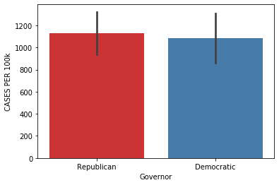

```python
#Print Barplot
sns.barplot(x='Governor', y='CASES PER 100k', data=df_rq1, palette='Set1')
```

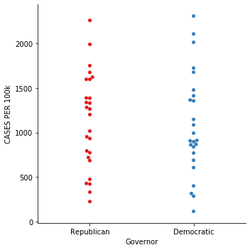

```python
#Print Categorical Plot
plot = sns.catplot(x='Governor', y='CASES PER 100k', kind='swarm', data=df_rq1, palette='Set1')
```

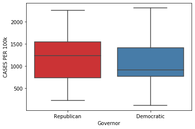

```python
#Print Boxplot
sns.boxplot(x='Governor', y='CASES PER 100k', data=df_rq1, palette='Set1')
```

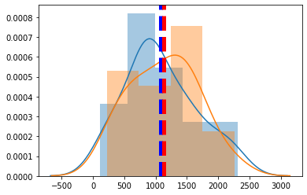

```python
#Assign 'CASES PER 100K' values to two lists based on the party of the Governor
cases_demoStates = df_rq1.loc[df_rq1['Governor'] == 'Democratic', 'CASES PER 100k'].tolist()
cases_repubStates = df_rq1.loc[df_rq1['Governor'] == 'Republican', 'CASES PER 100k'].tolist()

#Print Density Curve with Histogram
plt.figure()
ax1=sns.distplot(cases_demoStates)
ax2=sns.distplot(cases_repubStates)
plt.axvline(np.mean(cases_demoStates), color='blue', linestyle='dashed', linewidth=5)
plt.axvline(np.mean(cases_repubStates), color='red', linestyle='dashed', linewidth=5)
```

From the above plots, it is clear that there is no significant difference in covid cases per 100k between states ruled by Republican and Democratic Governors. Hence we fail to reject our null hypothesis.

We can notice, from the barplot and the density curve with histogram, that the mean covid cases per capita is sligtly more in the states governed by Republicans but is still very close to the mean of states ruled by Democrats. Also from the categorical plot, we can see that the distribution is quite the same between the two groups. The median count is a little less in the Democratic category but the highest and the lowest count are both in the same group which are evident in the boxplot.

#### Research Question 2:

```python
#Import data from excel
df_statePartisan = pd.DataFrame(pd.read_excel('Blue and Red States.xlsx'))

#Remove all the columns that are not required
del df_statePartisan[2004]
del df_statePartisan[2008]
del df_statePartisan[2012]
del df_statePartisan[2016]

#Remove junk values from the elements of STATE column
for i in df_statePartisan.index:
    df_statePartisan['STATE'].values[i] = df_statePartisan['STATE'].values[i].replace("\xa0", "")
    df_statePartisan['STATE'].values[i] = df_statePartisan['STATE'].values[i].replace("'", "")

#Print table with list of Red, Blue and Purple States
df_statePartisan
```

|  | STATE | State Partisanship |
| --- | --- | --- |
| 0 | Alabama | Red |
| 1 | Alaska | Red |
| 2 | Arizona | Red |
| 3 | Arkansas | Red |
| 4 | California | Blue |
| 5 | Colorado | Blue |
| 6 | Connecticut | Blue |
| 7 | Delaware | Blue |
| 8 | District of Columbia | Blue |
| 9 | Florida | Purple |
| 10 | Georgia | Red |
| 11 | Hawaii | Blue |
| 12 | Idaho | Red |
| 13 | Illinois | Blue |
| 14 | Indiana | Red |
| 15 | Iowa | Purple |
| 16 | Kansas | Red |
| 17 | Kentucky | Red |
| 18 | Louisiana | Red |
| 19 | Maine | Blue |
| 20 | Maryland | Blue |
| 21 | Massachusetts | Blue |
| 22 | Michigan | Blue |
| 23 | Minnesota | Blue |
| 24 | Mississippi | Red |
| 25 | Missouri | Red |
| 26 | Montana | Red |
| 27 | Nebraska | Red |
| 28 | Nevada | Blue |
| 29 | New Hampshire | Blue |
| 30 | New Jersey | Blue |
| 31 | New Mexico | Blue |
| 32 | New York | Blue |
| 33 | North Carolina | Red |
| 34 | North Dakota | Red |
| 35 | Ohio | Purple |
| 36 | Oklahoma | Red |
| 37 | Oregon | Blue |
| 38 | Pennsylvania | Blue |
| 39 | Rhode Island | Blue |
| 40 | South Carolina | Red |
| 41 | South Dakota | Red |
| 42 | Tennessee | Red |
| 43 | Texas | Red |
| 44 | Utah | Red |
| 45 | Vermont | Blue |
| 46 | Virginia | Blue |
| 47 | Washington | Blue |
| 48 | West Virginia | Red |
| 49 | Wisconsin | Blue |
| 50 | Wyoming | Red |

```python
#Merge columns from both the dataframes and assign to a new dataframe based on the state value
df_rq2 = pd.merge(df_coronaCases, df_statePartisan, how = 'inner', on= 'STATE')
df_rq2= df_rq2.rename(index=str, columns={" State Partisanship": "StatePartisanship"})

#Remove purple(swing) states
rows_to_delete = df_rq2[df_rq2['StatePartisanship'] == 'Purple'].index
df_rq2.drop(rows_to_delete, inplace=True)

#Export the dataframe to csv
df_rq2.to_csv('ResearchQuestion2.csv')

#Print the final table for RQ2
df_rq2
```

|  | STATE | CASES PER 100k | StatePartisanship |
| --- | --- | --- | --- |
| 0 | Alabama | 1622 | Red |
| 1 | Alaska | 421 | Red |
| 2 | Arizona | 2259 | Red |
| 3 | Arkansas | 1282 | Red |
| 4 | California | 1147 | Blue |
| 5 | Colorado | 769 | Blue |
| 6 | Connecticut | 1365 | Blue |
| 7 | Delaware | 1478 | Blue |
| 8 | District of Columbia | 1677 | Blue |
| 10 | Georgia | 1597 | Red |
| 11 | Hawaii | 114 | Blue |
| 12 | Idaho | 1016 | Red |
| 13 | Illinois | 1355 | Blue |
| 14 | Indiana | 932 | Red |
| 16 | Kansas | 862 | Red |
| 17 | Kentucky | 606 | Red |
| 18 | Louisiana | 2308 | Red |
| 19 | Maine | 285 | Blue |
| 20 | Maryland | 1386 | Blue |
| 21 | Massachusetts | 1675 | Blue |
| 22 | Michigan | 867 | Blue |
| 23 | Minnesota | 912 | Blue |
| 24 | Mississippi | 1751 | Red |
| 25 | Missouri | 684 | Red |
| 26 | Montana | 315 | Red |
| 27 | Nebraska | 1264 | Red |
| 28 | Nevada | 1412 | Blue |
| 29 | New Hampshire | 474 | Blue |
| 30 | New Jersey | 2013 | Blue |
| 31 | New Mexico | 897 | Blue |
| 32 | New York | 2107 | Blue |
| 33 | North Carolina | 1085 | Red |
| 34 | North Dakota | 773 | Red |
| 36 | Oklahoma | 793 | Red |
| 37 | Oregon | 400 | Blue |
| 38 | Pennsylvania | 839 | Blue |
| 39 | Rhode Island | 1724 | Blue |
| 40 | South Carolina | 1597 | Red |
| 41 | South Dakota | 952 | Red |
| 42 | Tennessee | 1388 | Red |
| 43 | Texas | 1330 | Red |
| 44 | Utah | 1201 | Red |
| 45 | Vermont | 224 | Blue |
| 46 | Virginia | 993 | Blue |
| 47 | Washington | 688 | Blue |
| 48 | West Virginia | 330 | Red |
| 49 | Wisconsin | 906 | Blue |
| 50 | Wyoming | 428 | Red |

Now, we have the data set ready for our second research question which is,

Is there a mean difference in covid cases per capita between Red(Conservatives) and Blue(Liberal) States?

Note: The terms Red State and Blue State may vary in different contexts. For our research, as stated earlier, we consider 'Red States' as states where voters largely choose Republican Party and Blue States are states where voters predominantly choose Democratic Party during Presidential election. The data we have is based on the last 4 Presidential elections(2004-2016). Kindly refer https://en.wikipedia.org/wiki/Red_states_and_blue_states for more information.

Our research hypotheses:

H0 (Null Hypothesis) - There is no significant difference in the covid cases per capita between Red and Blue States.

H1 (Alternative Hypothesis) - There is significant difference in the covid cases per capita between Red and Blue States.

We will plot few graphs and find out if there is a significant difference

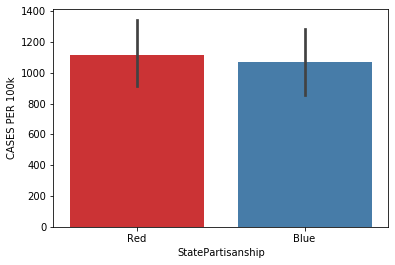

```python
#Print Barplot
sns.barplot(x='StatePartisanship', y='CASES PER 100k', data=df_rq2, palette='Set1')
```

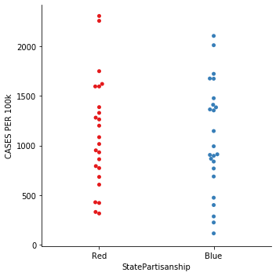

```python
#Print Categorical Plot
plot = sns.catplot(x='StatePartisanship', y='CASES PER 100k', kind='swarm', data=df_rq2, palette='Set1')
```

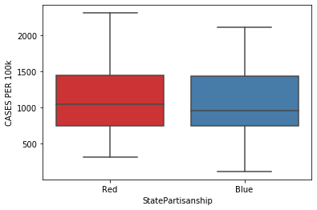

```python
#Print Box Plot
sns.boxplot(x='StatePartisanship', y='CASES PER 100k', data=df_rq2, palette='Set1')
```

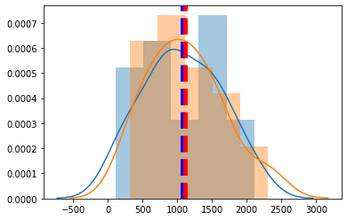

```python
#Assign 'CASES PER 100K' values to two lists based on the partisanship of states
cases_blueStates = df_rq2.loc[df_rq2['StatePartisanship'] == 'Blue', 'CASES PER 100k'].tolist()
cases_redStates = df_rq2.loc[df_rq2['StatePartisanship'] == 'Red', 'CASES PER 100k'].tolist()

#Print Density Curve with Histogram
plt.figure()
ax1=sns.distplot(cases_blueStates)
ax2=sns.distplot(cases_redStates)
plt.axvline(np.mean(cases_blueStates), color='blue', linestyle='dashed', linewidth=5)
plt.axvline(np.mean(cases_redStates), color='red', linestyle='dashed', linewidth=5)
```

Even in this case, we fail to reject null hypothesis as we can see no significant difference in covid cases per 100k between the red and blue states.

We can observe that the mean of the covid cases per 100k is slightly more in Red states than in the Blue states, similar to what we noticed in the plots of previous research question. Also, the median is slightly greater in the red state category than in the blue. From the visualizations, we can also note that the highest value of cases per capita is in a Red state and the lowest is in a Blue state.

### Statistical Analysis:

We can understand the differences enough from the visualizations but we will still go one step further and perform some Statistical Analysis, considering these data to be samples, as the count reported could vary from the actual data and in addition to that, the count on cases keeps changing every day and the data we have is already 2 weeks old.

We will now perform two sample t-tests on the following research questions,

1. Is there a mean difference in covid cases (dependent variable) per capita between states ruled by Republican and Democratic Governors(independent variables)?
2. Is there a mean difference in covid cases (dependent variable) per capita between Red and Blue States(independent variables)?

In order to do this, we will have to test the following assumptions, at first.

1. Assumption of normality of the dependent variables
2. Assumption of homogeneity of variance

For testing the first assumption, we will make use of Shapiro-Wilk test and for the second assumption, we will make use Levene's test

#### Research Question 1:

```python
#Test the assumption of normality of the dependent variable using Shapiro-Wilk test
def normality_assumption(cases):
    from scipy.stats import shapiro
    stat, p = shapiro(cases)
    print('Shapiro p=%.3f'%p)
    if p>0.05:
        print('Therefore data is drawn from a Gaussian distribution')
    else:
        print('Therefore data is not drawn from a Gaussian distribution')

#Test the assumption of homogeneity of variance using Levene's test
def equalvar_assumption(cases1, cases2):
    from scipy.stats import levene
    stat, pvalue = levene(cases1, cases2)
    print('Levene p=%.3f'%pvalue)
    if pvalue>0.05:
        print('Therefore the two groups have equal variances')
    else:
        print('Therefore the two groups do not have equal variances')

normality_assumption(cases_repubStates)
normality_assumption(cases_demoStates)
equalvar_assumption(cases_demoStates, cases_repubStates)
```

```
Shapiro p=0.717
Therefore data is drawn from a Gaussian distribution
Shapiro p=0.541
Therefore data is drawn from a Gaussian distribution
Levene p=0.991
Therefore the two groups have equal variances
```

Now that the assumptions are met, we can proceed with the two independent sample t-test.

```python
#Function to perform two independent sample t-test
def ind_sample_ttest(array1, array2, alpha):
    tstat,p = ttest_ind(array1,array2)
    print('t Test Statistic=%.3f, p=%.3f' % (tstat,p))
    if p > alpha:
        print('No significant difference. Fail to reject H0')
    else:
        print('Significant difference. Reject H0')

#Function call with required parameters
ind_sample_ttest(cases_demoStates,cases_repubStates,0.05)
```

```
t Test Statistic=-0.300, p=0.766
No significant difference. Fail to reject H0
```

Since the p value is more than the alpha value of .05, we fail to reject the null hypothesis and state that the means of covid cases per capita were not statistically significantly different for states with Rupublican and Democratic Governors.

#### Research Question 2:

```python
#Test the assumption of normality by calling the normality_assumption function defined above for both the dependent variables
normality_assumption(cases_blueStates)
normality_assumption(cases_redStates)

#Test the assumption of homogeneity of variance by calling the equalvar_assumption function defined above
equalvar_assumption(cases_blueStates, cases_redStates)
```

```
Shapiro p=0.679
Therefore data is drawn from a Gaussian distribution
Shapiro p=0.378
Therefore data is drawn from a Gaussian distribution
Levene p=0.867
Therefore the two groups have equal variances
```

The assumptions are met and we will proceed with the two independent sample t-test.

```python
#Perform t-test by calling the ind_sample_ttest function defined above
ind_sample_ttest(cases_blueStates,cases_redStates,0.05)
```

```
t Test Statistic=-0.283, p=0.779
No significant difference. Fail to reject H0
```

The p value is more than the alpha value of 0.05. Therefore, we fail to reject the null hypothesis and state that the means of covid cases per capita were not statistically significantly different for the red states and blue states.

### Results:

In this paper, we studied difference in covid cases per capita between states ruled by Republican and Democratic Governors and also between Red and Blue states(conservative and liberal states). From the visualizations, we were able to discern that the difference was not significant for both the cases. We also conducted independent sample t test. The assumption of normality was tested and satisfied for the distributional shape of the dependent variable (cases per 100k) for states with Republican Governors and states with Democratic Governors and for red and blue states. Review of the Shapiro-Wilk test for normality suggested that the normality of dependent variables was a reasonable assumption. According to Levene's test, the homogeneity of variance assumption was met. As there was no random assignment to states, the assumption of independence was not met and this creates a potential for increased probability of Type 1 and Type 2 error.

The independent t test indicated that the covid 'cases per capita' means were not statistically significantly different for states ruled by Republican Governors and Democratic Governors. There was also no statistically significant difference between Red and Blue states. Thus, the null hypothesis that the means are same by partisanship of Governors or people in the states was accepted at the .05 level of significance.

### Conclusion:

Though the response to this pandemic appears to be structured by partisanship, covid cases per capita does not seem to be influenced by the polarity, at least at the moment. In spite of this, there is undoubtedly a need to present a united front and forge a consensus to fight this virus. There are limitations to this study. Firstly, we only have considered covid cases per 100k and not taken any other parameter for arriving at this conclusion. Secondly, there are possibilities of increased number of cases in certain states because of the neighboring states. Future studies could focus on other indicators like Rate of Positive Tests and study further on how people's response, to Social Distancing measures and other public health guidelines, vary based on the partisanship of states.

### References:

https://www.bbc.com/news/world-51235105

https://www.washingtonpost.com/nation/2020/08/03/coronavirus-covid-live-updates-us/

https://www.pewresearch.org/politics/2020/06/25/republicans-democrats-move-even-further-apart-in-coronavirus-concerns/

https://en.wikipedia.org/wiki/List_of_United_States_governors

https://en.wikipedia.org/wiki/Red_states_and_blue_states

An Introduction to Statistical Concepts, Third Edition by Richard G. Lomax, Debbie L. Hahs‐Vaughn https://onlinelibrary.wiley.com/doi/abs/10.1111/j.1751-5823.2012.00196_21.x